# Untitled

Frank Edwards

3/8/2021

## Homework 5

Who was most (and least) likely to die on the Titanic? Use `~/hw/data/titanic.csv` for this one.

```r
## set up packages and rstan options
library(tidyverse)
library(rstan)
library(rstanarm)
rstan_options(auto_write = TRUE)
options(mc.cores = parallel::detectCores())
### read in data
dat<-read_csv("./data/titanic.csv")
```

1. Write out a model

This is a model that says survival probability is a linear function of age, sex, and passenger class

$$logit(p_i) = \beta_0 + \beta_1 age_i + \beta_2 pclass_i + \beta_3sex_i$$
$$Survival_i \sim Binomial(1, p_i)$$

2. Fit the model

```r
### frequentist
m1<-glm(Survived ~ Age + Pclass + Sex,
        data = dat,
        family = "binomial")

### bayesian
m1_b<-stan_glm(Survived ~ Age + Pclass + Sex,
        data = dat,
        family = "binomial")
### display the fits
coef(m1)
```

```
## (Intercept)         Age      Pclass     Sexmale
##  4.87851130 -0.03436144 -1.23053773 -2.58916304
```

```r
coef(m1_b)
```

```
## (Intercept)         Age      Pclass     Sexmale
##  4.90608147 -0.03456397 -1.23645522 -2.59692979
```

```r
### cool that looks similar
```

Interpreting these fits. Let’s look at survival as a function of age/sex/class

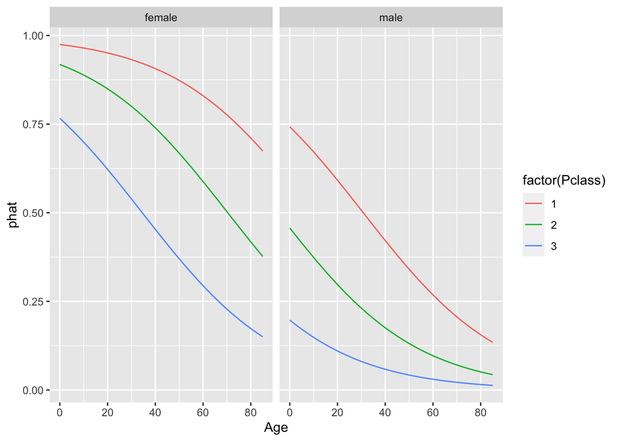

```r
Age<-0:85
Sex<-c("male", "female")
Pclass<-1:3
### expand_grid is really useful to make a tibble with all possible
### combinations of provided variables
fake_data<-expand_grid(Age, Sex, Pclass)

### frequentist prediction to start
fake_data<-fake_data %>%
  mutate(phat = predict(m1, newdata = fake_data,
                        type = "response"))
### plot it
ggplot(fake_data,
       aes(x = Age, y = phat,
           color = factor(Pclass))) +
  geom_line() +
  facet_grid(~Sex)
```

3. Think about revising the model

Maybe the impact of age depends on sex and passenger class, that is first class boys may be more likely to survive than 3rd class women?

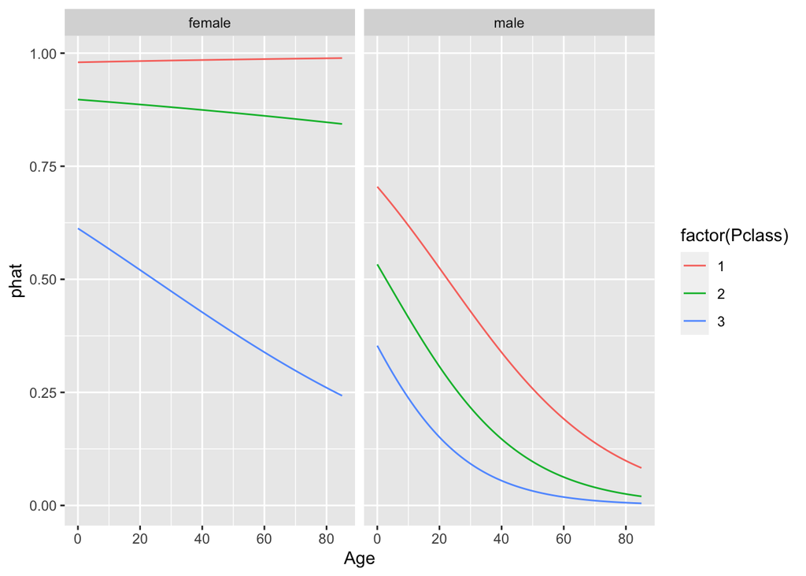

```r
m2<-glm(Survived ~ Age * Pclass * Sex,
        data = dat,
        family = "binomial")

m2_b<-stan_glm(Survived ~ Age * Pclass * Sex,
        data = dat,
        family = "binomial")

fake_data<-fake_data %>%
  mutate(phat = predict(m2, fake_data,
                        type = "response"))

ggplot(fake_data,
       aes(x = Age, y = phat,
           color = factor(Pclass))) +
  geom_line() +
  facet_grid(~Sex)
```

Yep! That’s a really different fit for 1st and 2nd class women! Basically, no 1st class women died.

4. Compare model fits

```r
BIC(m1)
```

```
## [1] 828.7641
```

```r
BIC(m2)
```

```
## [1] 826.3235
```

```r
### for bayesian models, we can do leave one out
loo_m1<-loo(m1_b)
loo_m2<-loo(m2_b)
loo_compare(loo_m1, loo_m2)
```

```
##      elpd_diff se_diff
## m2_b   0.0       0.0
## m1_b -10.5       5.6
```

M2 has a slightly smaller BIC, so there’s a slight preference to the frequentist model m2. When using leave one out cross validation with the Bayesian models, m2 does appear to fit the data better than m1.

5. Interpret the model